# Lab 9 - HPC

# Learning goals

In this lab, you are expected to practice the following skills:

- Evaluate whether a problem can be parallelized or not.
- Practice with the parallel package.
- Use Rscript to submit jobs.

## Problem 1

Give yourself a few minutes to think about what you learned about parallelization. List three examples of problems that you believe may be solved using parallel computing, and check for packages on the HPC CRAN task view that may be related to it.

Monte Carlo Simulations - Many iterations of random sampling can be parallelized. Related package: parallel, foreach.

Genome-Wide Association Studies (GWAS) - Large-scale computations on genetic data can be parallelized. Related package: BiocParallel.

Image Processing (e.g., edge detection, filtering) - Parallel processing of image pixels can speed up performance. Related package: future.apply.

## Problem 2: Pre-parallelization

The following functions can be written to be more efficient without using `parallel`:

1. This function generates a `n x k` dataset with all its entries having a Poisson distribution with mean `lambda`.

```r
fun1 <- function(n = 100, k = 4, lambda = 4) {
  x <- NULL

  for (i in 1:n)
    x <- rbind(x, rpois(k, lambda))

  return(x)
}

fun1alt <- function(n = 100, k = 4, lambda = 4) {
 matrix(rpois(n * k, lambda), nrow = n, ncol = k)
}

# Benchmarking
microbenchmark::microbenchmark(
  fun1(),
  fun1alt()
)
```

```
## Unit: microseconds
##       expr    min       lq      mean  median       uq      max neval
##     fun1() 99.835 108.1580 169.34927 109.593 110.8640 6105.064   100
##  fun1alt()  8.897   9.4505  15.72104   9.635  10.3525  565.103   100
```

How much faster?

2. Find the column max (hint: Checkout the function `max.col()`).

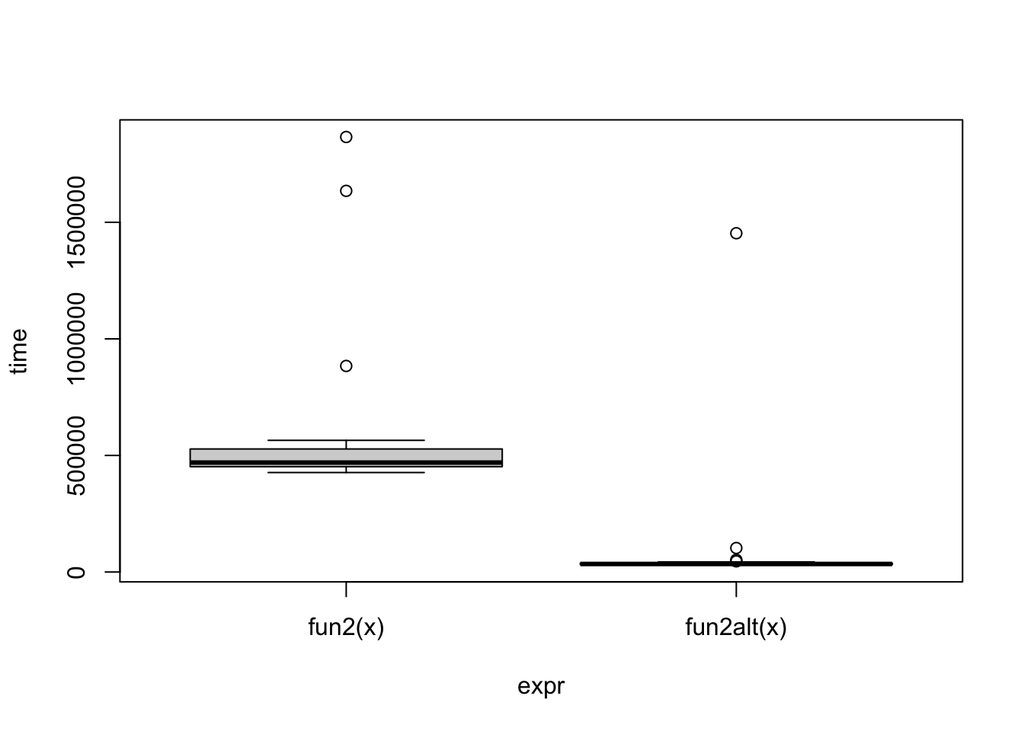

```r
# Data Generating Process (10 x 10,000 matrix)
set.seed(1234)
x <- matrix(rnorm(1e4), nrow=10)

# Find each column's max value
fun2 <- function(x) {
  apply(x, 2, max)
}

fun2alt <- function(x) {
  x[max.col(t(x), ties.method = "first") + (0:(ncol(x)-1))*nrow(x)]
}

# Benchmarking
library(ggplot2)
library(microbenchmark)

benchmark_results <- microbenchmark(
  fun2(x),
  fun2alt(x)
)

# Plotting the benchmark results
plot(benchmark_results)
```

*Answer here with a plot.*

## Problem 3: Parallelize everything

We will now turn our attention to non-parametric bootstrapping. Among its many uses, non-parametric bootstrapping allow us to obtain confidence intervals for parameter estimates without relying on parametric assumptions.

The main assumption is that we can approximate many experiments by resampling observations from our original dataset, which reflects the population.

This function implements the non-parametric bootstrap:

```r
  library(parallel)

my_boot <- function(dat, stat, R, ncpus = 1L) {

  # Getting the random indices
  n <- nrow(dat)
  idx <- matrix(sample.int(n, n*R, TRUE), nrow=n, ncol=R)

  # Making the cluster using `ncpus`
  cl <- makeCluster(ncpus)
  clusterExport(cl, varlist = c("dat", "stat", "idx"), envir = environment())

  # Running parallel bootstrapping
  ans <- parLapply(cl, seq_len(R), function(i) {
    stat(dat[idx[,i], , drop=FALSE])
  })

  stopCluster(cl)

  # Coercing the list into a matrix
  ans <- do.call(rbind, ans)

  ans
}
```

1. Use the previous pseudocode, and make it work with `parallel`. Here is just an example for you to try:

```r
# Bootstrap of a linear regression model
my_stat <- function(dat) {
  coef(lm(y ~ x, data = dat))
}

# DATA SIM
set.seed(1)
n <- 500
R <- 1000
x <- rnorm(n)
y <- x*5 + rnorm(n)
dat <- data.frame(x, y)

# Check if we get something similar as lm
ans0 <- confint(lm(y ~ x, data = dat))
ans1 <- my_boot(dat, my_stat, R, ncpus = 2)

# Checking bootstrap results
apply(ans1, 2, quantile, probs = c(0.025, 0.975))
```

```
##       (Intercept)        x
## 2.5%  -0.14307029 4.868525
## 97.5%  0.05292241 5.048437
```

2. Check whether your version actually goes faster than the non-parallel version:

```r
microbenchmark::microbenchmark(
  my_boot(dat, my_stat, R, ncpus = 1),
  my_boot(dat, my_stat, R, ncpus = 2)
)
```

```
## Unit: milliseconds
##                                 expr      min       lq     mean   median
##  my_boot(dat, my_stat, R, ncpus = 1) 321.1386 325.7067 327.7570 327.3988
##  my_boot(dat, my_stat, R, ncpus = 2) 221.1608 223.9967 225.4556 225.0161
##        uq      max neval
##  329.5359 336.3094   100
##  226.0751 269.9967   100
```

## Problem 4: Compile this markdown document using Rscript

Once you have saved this Rmd file, try running the following command in your terminal:

```bash
Rscript --vanilla -e 'rmarkdown::render("[full-path-to-your-Rmd-file.Rmd]")' &
```

Where `[full-path-to-your-Rmd-file.Rmd]` should be replace with the full path to your Rmd file… :).